[figure not shown]

CS F364: Design and Analysis of Algorithms

# Dynamic Programming: Fibonacci & LCS

Lecture 10 |2026-06-02

# Introduction to Dynamic Programming

- Introduction to Dynamic Programming
- Longest Common Subsequence

## Fibonacci Numbers: A Recursive Approach

The Fibonacci sequence is defined by the recurrence:
$$F_n =
\begin{cases}
0 & \text{if } n=0\\
1 & \text{if } n=1\\
F_{n-1} + F_{n-2} & \text{otherwise}
\end{cases}$$

A direct recursive translation to compute the $n^{\text{th}}$ Fibonacci number:

```javascript
function rFib(n) {
    if (n <= 1) return n;
    return rFib(n - 1) + rFib(n - 2);
}
```

## Complexity of Recursion

Let $T(n)$ be the number of operations to compute $F_n$:
$$T(n) = T(n-1) + T(n-2) + 1$$
$$T(0) = T(1) = 1$$

The solution to this recurrence is:
$$T(n) = O(\phi^n) \quad \text{where } \phi = \frac{\sqrt{5}+1}{2} \approx 1.618$$

- **The algorithm runs in exponential time!**
- There is a massive amount of redundant computation.

## Recursion Tree

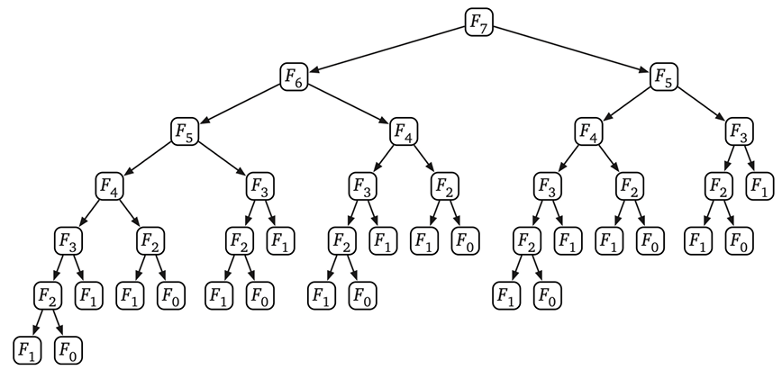

Recursion Tree for Fibonacci

- **Redundant Computation:** Subproblems like $F_{n-2}$, $F_{n-3}$, etc. are solved repeatedly.
- **The Solution:** Can we memoize intermediate computation results to avoid recomputation?

## Fibonacci Numbers: An Iterative Approach

Instead of top-down recursion, we can compute solutions bottom-up and store them in an array:

```javascript
function iterativeFib(n) {
    let F = new Array(n + 1);
    F[0] = 0;
    F[1] = 1;
    for (let i = 2; i <= n; i++) {
        F[i] = F[i - 1] + F[i - 2];
    }
    return F[n];
}
```

- **Time Complexity:** $O(n)$ – linear time!
- **Space Complexity:** $O(n)$ (which can be optimized to $O(1)$).

## The Core Philosophy & Properties of Dynamic Programming

**The Core Philosophy:** Solve each subproblem *exactly once* and store the result to avoid redundant calculations—trading space for time.

### Two Essential Properties

1. **Optimal Substructure:** An optimal solution to the problem can be constructed efficiently from the optimal solutions of its subproblems.
2. **Overlapping Subproblems:** The recursive search space contains the *same* subproblems repeatedly, rather than generating new independent subproblems at each step.

# Longest Common Subsequence

- Introduction to Dynamic Programming
- Longest Common Subsequence

## Text Similarity

- Biological applications often need to compare the DNA of two (or more) different organisms.
- Eg: The DNA of an organism may be $S_1 = \text{ACCGGTCGAGTGCGCGGAAGCCGGCCGAA}$, and the DNA of another organism may be $S_2 = \text{GTCGTTCGGAATGCCGTTGCTCTGTAAA}$.
- **Comparing these two helps a biologist to determine how closely related both organisms are.**

## Subsequence

Given a sequence $X = \langle x_1, x_2, \ldots, x_m \rangle$, another sequence $Z = \langle z_1, z_2, \ldots, z_k \rangle$ is a **subsequence** of $X$ if there exists a strictly increasing sequence $\langle i_1, i_2, \ldots, i_k \rangle$ of indices of $X$ such that for all $j = 1, 2, \ldots, k$, we have $x_{i_j} = z_j$.

**Example:** $Z = \langle B, C, D, B \rangle$ is a subsequence of $X = \langle A, B, C, B, D, A, B \rangle$ with corresponding index sequence $\langle 2, 3, 5, 7 \rangle$.

## Common Subsequence

Given two sequences $X$ and $Y$, we say that $Z$ is a **common subsequence** of $X$ and $Y$ if $Z$ is a subsequence of both $X$ and $Y$.

**Example:** $Z = \langle B, C, B, A \rangle$ is a common subsequence of $X = \langle A, B, C, B, D, A, B \rangle$ and $Y = \langle B, D, C, A, B, A \rangle$.

## Longest Common Subsequence Problem

Given two sequences $X = \langle x_1, x_2, \ldots, x_m \rangle$ and $Y = \langle y_1, y_2, \ldots, y_n \rangle$, the goal is to find a **maximum length** common subsequence of $X$ and $Y$.

**Brute Force Method:**

- Enumerate all subsequences of $X$.
- Check each subsequence to see whether it is also a subsequence of $Y$.
- Keep track of the longest subsequence found.
- Each subsequence of $X$ corresponds to a subset of indices $\{1, 2, \ldots, m\}$.
- Number of subsequences: $2^m$.
- Running time: exponential!

## DP Formulation for LCS

- The DP formulation is based on pairs of prefixes.
- A prefix of $X = \langle x_1, \ldots, x_n \rangle$ is $X_i = \langle x_1, \ldots, x_i \rangle$. $X_0$ is the empty sequence.
- Let $\text{lcs}(i, j)$ denote the **length** of the longest common subsequence of $X_i$ and $Y_j$.

**Optimal Substructure**

Let $Z = \langle z_1, \ldots, z_k \rangle$ be any LCS of $X$ and $Y$.

- If $x_m = y_n$, then $z_k = x_m = y_n$ and $Z_{k-1}$ is an LCS of $X_{m-1}$ and $Y_{n-1}$.
- If $x_m \neq y_n$, then $Z$ is an LCS of $X_{m-1}$ and $Y$ (if $z_k \neq x_m$) or of $X$ and $Y_{n-1}$ (if $z_k \neq y_n$).

## Observations – Case 1

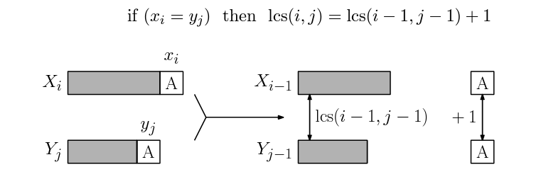

If $x_i = y_j$, then $\text{lcs}(i, j) = \text{lcs}(i-1, j-1) + 1$.

## Observations – Case 2

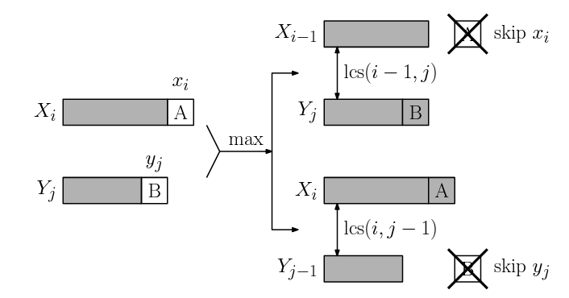

If $x_i \neq y_j$, then $\text{lcs}(i, j) = \max(\text{lcs}(i-1, j), \text{lcs}(i, j-1))$.

## DP Recurrence

$$\text{lcs}(i, j) =
\begin{cases}
0 & \text{if } i = 0 \text{ or } j = 0 \\
\text{lcs}(i-1, j-1) + 1 & \text{if } x_i = y_j \\
\max(\text{lcs}(i-1, j), \text{lcs}(i, j-1)) & \text{if } x_i \neq y_j
\end{cases}$$

## DP Algorithm – Top-Down Memoized Version

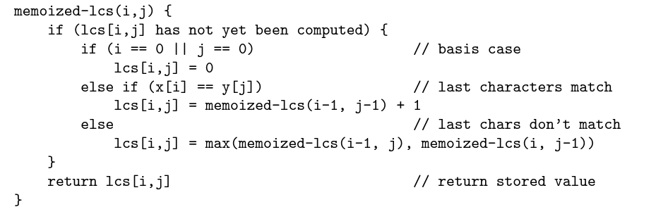

## DP Algorithm – Bottom-Up Tabulation Version

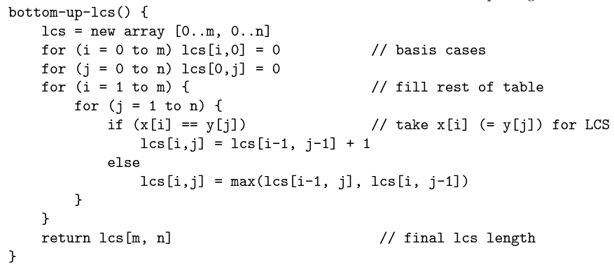

## Extracting the LCS

The algorithms above compute only the **length** of the LCS. We save extra direction flags (hints) in a table $b[1..m, 1..n]$ to recover the actual sequence.

Three flags maintained during the LCS algorithm:

1. $\nwarrow$ : Add $x_i (= y_j)$ to the LCS and continue with $\text{lcs}(i-1, j-1)$.
2. $\uparrow$ : Skip $x_i$ and continue with $\text{lcs}(i-1, j)$.
3. $\leftarrow$ : Skip $y_j$ and continue with $\text{lcs}(i, j-1)$.

## Reconstructing the LCS (Backtracking)

We backtrack from the bottom-right corner $b[m, n]$ of the table to the start ($i=0$ or $j=0$):

```javascript
function printLCS(b, X, i, j) {
    if (i === 0 || j === 0) return;

    if (b[i][j] === "↖") {
        printLCS(b, X, i - 1, j - 1);
        print(X[i]); // Output character (part of LCS)
    } else if (b[i][j] === "↑") {
        printLCS(b, X, i - 1, j);
    } else {
        printLCS(b, X, i, j - 1);
    }
}
```

- **Time Complexity:** $O(m + n)$ – we decrement at least one index ($i$ or $j$) in each step.

## Example

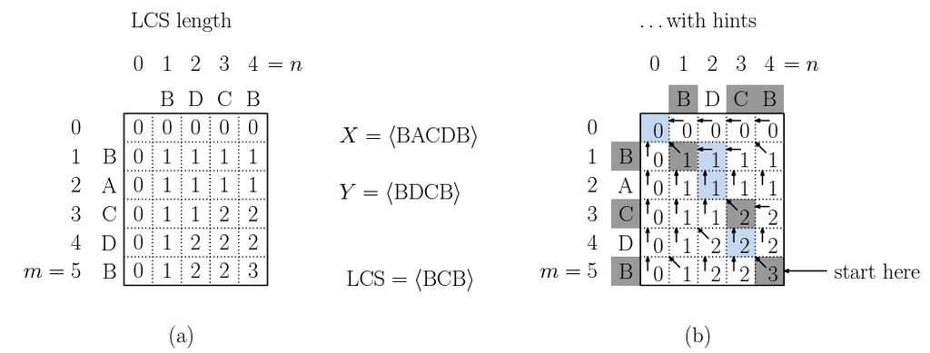

## References

- Michael T. Goodrich and Roberto Tamassia, *Algorithm Design: Foundations, Analysis, and Internet Examples*, Wiley Student Edition.
- Jon Kleinberg and Eva Tardos, *Algorithm Design*, Pearson Publishers.
- Thomas H. Cormen, Charles E. Leiserson, Ronald L. Rivest, and Clifford Stein, *Introduction to Algorithms*, MIT Press.
- Sanjoy Dasgupta, Christos Papadimitriou, and Umesh Vazirani, *Algorithms*, McGraw-Hill.